# ML prediction of Mortality

  **Note:** This is expected if your dataset is **highly imbalanced**, e.g., deaths are a small fraction of total samples. Logistic regression tends to predict the **majority class poorly for specificity** unless you handle class imbalance.

```r
## predicting the probabilities
pred_probs1 <- predict(cv_model1, newdata = test_data, type = "prob")$Yes
pred_probs2 <- predict(cv_model2, newdata = test_data, type = "prob")$Yes

## Checking ROC
rocCV1 <- roc(test_data$inddea, pred_probs1)
rocCV2 <- roc(test_data$inddea, pred_probs2)
roc.test(rocCV1, rocCV2)
```

```
##
##  DeLong's test for two correlated ROC curves
##
## data:  rocCV1 and rocCV2
## Z = -4.1421, p-value = 3.442e-05
## alternative hypothesis: true difference in AUC is not equal to 0
## 95 percent confidence interval:
##  -0.0016042649 -0.0005736924
## sample estimates:
## AUC of roc1 AUC of roc2
##   0.8517497   0.8528387
```

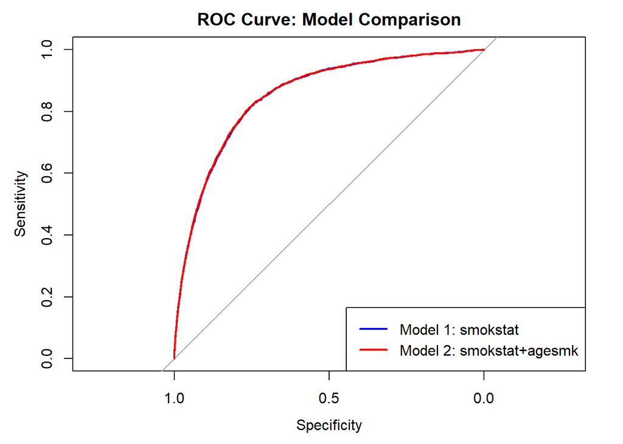

```r
# ROC Plot
plot(rocCV1, col = "blue", main = "ROC Curve: Model Comparison")
lines(rocCV2, col = "red")
legend("bottomright", legend = c("Model 1: smokstat", "Model 2: smokstat+agesmk"),
       col = c("blue", "red"), lwd = 2)
```

The AUCs of SmokingStatus model`rocCV1` (0.852) and SmokingStatus + SmokingDuration model `rocCV2` (0.853) are very similar, and the small but statistically significant difference (p ≈ 3.44e-5) indicates `rocCV2` has a slightly higher discriminatory performance.

The models have **excellent discrimination**, meaning it can rank individuals from low to high mortality risk quite well

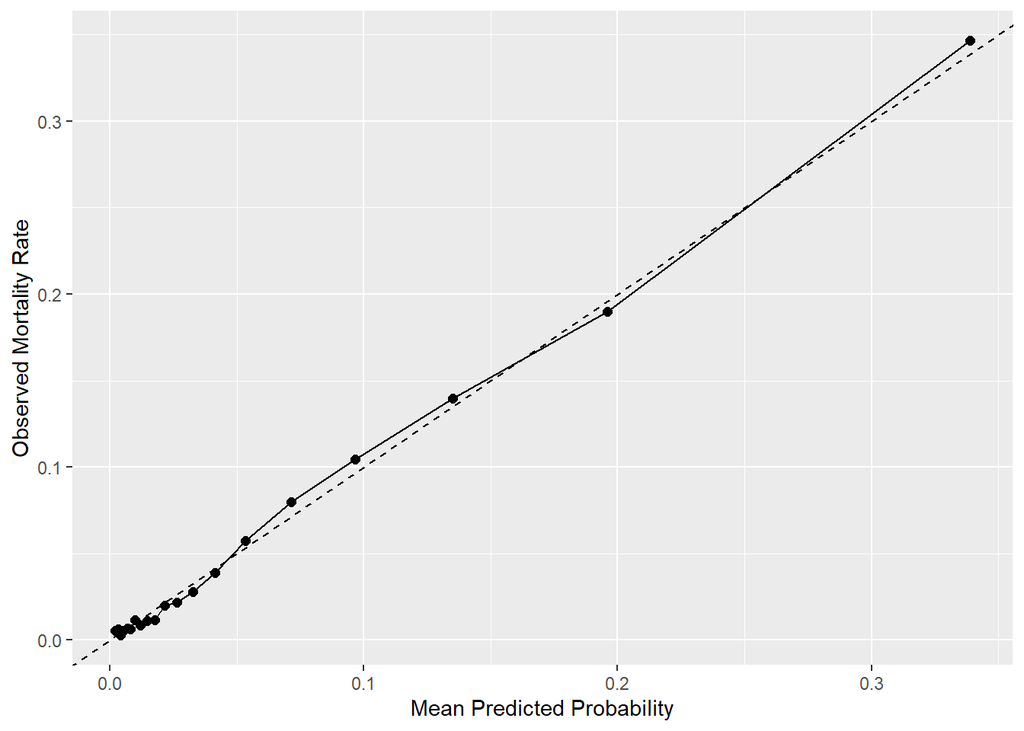

```r
## Model1 Calibration

cal_data1 <- data.frame(
  obs = test_data$inddea,
  pred = pred_probs1
)

cal_data2 <- data.frame(
  obs = test_data$inddea,
  pred = pred_probs2
)

## Method 1 : Manual Binning

cal_plot <- cal_data1 %>%
  mutate(bin = ntile(pred, 20)) %>%
  group_by(bin) %>%
  summarise(
    mean_pred = mean(pred),
    obs_rate = mean(as.numeric(obs) - 1),
    n = n()
  )

ggplot(cal_plot, aes(x = mean_pred, y = obs_rate)) +
  geom_point(size = 2) +
  geom_line() +
  geom_abline(slope = 1, intercept = 0, linetype = "dashed") +
  labs(x = "Mean Predicted Probability",
       y = "Observed Mortality Rate")
```